# Assignment 2

Katarina and Tim

23 March 2018

# Setup

```r
library(tidyverse)
```

```r
library(ggplot2)
library(ggmosaic)
```

## Tidying the data

```r
cleaned_survey <- read.csv("data/survey.csv") %>%
  #Q1 - What year of uni are you in?
  #Convert letters to corresponding number values
  mutate(Q1=ifelse(Q1=="A",1,ifelse(Q1=="B",2,ifelse(Q1=="C",3,ifelse(Q1=="D",4,ifelse(Q1=="E",5,NA)))))) %>%

  #Q2 - How much time do you spend commuting to uni each week? (hours)
  #Seperate unnecessary characters into "rubbish" column to be deleted
  separate(Q2,c("Q2","rubbish"),sep=" ") %>% separate(Q2,c("Q2","rubbish"),sep="h") %>% separate(Q2,c("Q2","rubbish"),sep="H") %>%
  #then convert fractions to decimals
  mutate(Q2=ifelse(Q2=="1/2",0.5,ifelse(Q2=="4/7",0.57,ifelse(Q2=="4\n",4,Q2)))) %>% select(-rubbish) %>% mutate(Q2=as.numeric(Q2)) %>%

  #Q3 - I attended Ed Sheeran's concert in 2018?
  #No cleaning needed

  #Q4 - What is your favourite genre of music?
  #Compile similar answers into categories; if category only has one entry put in "Other"
  mutate(Q4=ifelse(Q4 %in% c("alt rock","Alternative Rock","Indie rock"),"Alternative Rock",ifelse(Q4 %in% c("classical","Classical"),"Classical",ifelse(Q4 %in% c("hip-hop", "hip-pop","hip,hop","Hip hop","Hip Hop","Hiphop"),"Hip-hop",ifelse(Q4 %in% c("jazz","Jazz"),"Jazz",ifelse(Q4 %in% c("pop","Pop","pop music","Pop music","popular"),"Pop",ifelse(Q4 %in% c("R&B","RnB","RNB","rnb"),"RnB",ifelse(Q4 %in% c("Rap"),"Rap",ifelse(Q4 %in% c("Rock","Rock and/or Roll"),"Rock","Other"))))))))) %>%

  #Q5 - How much time do you spend on the internet each week? (hours)
  #Seperate unnecessary characters into "rubbish" column to be deleted
  separate(Q5,c("Q5","rubbish2"),sep=" ") %>% separate(Q5,c("Q5","rubbish2"),sep="h") %>% separate(Q5,c("Q5","rubbish2"),sep="H") %>% select(-rubbish2) %>%
  mutate(Q5=ifelse(Q5=="C",NA,ifelse(Q5=="-",NA,Q5))) %>%

  #Q6 - If you could have a super power what would it be?
  #Compile similar answers into categories; if category only has one entry put in "Other"
  mutate(Q6=ifelse(Q6 %in% c("Flight","fly","flying","Flying"),"Flight",ifelse(Q6 %in% c("forecasting","forecast the future","predict the future"),"Predict the future",ifelse(Q6 %in% c("Control time", "time control","time travel","Time travel","time","go back to a past time","can go to wherever i want in any time","Time-Reverse"),"Time control/travel",ifelse(Q6 %in% c("invisible","invisibility","Invisible","Invisibility"),"Invisibility",ifelse(Q6 %in% c("Never forget","remember everything I saw"),"Memory",ifelse(Q6 %in% c("Teleportation","teleporting","teleportation"),"Teleportation",ifelse(Q6 %in% c("Telekinesis"),"Telekinesis",ifelse(Q6 %in% c("speed","Super-speed"),"Speed","Other"))))))))) %>%

  #Q7 - Would you rather your shirts always be two sizes too big or one size too small?
  #Convert letters into corresponding answers
  mutate(Q7=ifelse(Q7=="A","Two sizes too big",ifelse(Q7=="B","One size too small",ifelse(Q7=="C","Neither",NA)))) %>%

  #Q8 - How many hours do you spend studying per week?
  #Convert letters into corresponding number intervals
  mutate(Q8=ifelse(Q8=="A","0-3",ifelse(Q8=="B","3-6",ifelse(Q8=="C","6-9",ifelse(Q8=="D","9-12",ifelse(Q8=="E",">12",NA)))))) %>%

  #Q9- Which streaming service do you use to watch TV?
  #Compile similar answers into categories; if category only has one entry put in "Other"
  mutate(Q9=ifelse(Q9 %in% c("Don't watch television","dont wacth","dont watch tv","I do not watch television.","I don't","I don't watch television.","I don't watch television","i don't watch tv","No television","no idea","none","None","Nothing"),"Don't watch TV",ifelse(Q9 %in% c("Netflix","netflix","Netflix & Stan"),"Netflix",ifelse(Q9 %in% c("stan", "Stan"),"Stan",ifelse(Q9 %in% c("youtube","youtube, netflix"),"Youtube","Other"))))) %>%

  #Q10 - How many litres of water do you drink a day?
  #Remove invalid response "?"
  mutate(Q10=ifelse(Q10=="?",NA,Q10)) %>%

  #Q11 - Are you taking this subject as an elective or core unit?
  #Convert letters to corresponding answers
  mutate(Q11=ifelse(Q11=="A","elective","core")) %>%

  #Q12 - Do you study a single or double degree?
  #Convert letters to corresponding answers
  mutate(Q12=ifelse(Q12=="A","single","double")) %>%

  #Q13 - How much do you spend on food each day on average?
  #Separate unnecessary characters into 'rubbish column to be deleted
  separate(Q13,c("Q13","rubbish3"),sep=" ") %>% select(-rubbish3) %>%
  #remove dollar signs from remaining responses
  mutate(Q13=ifelse(Q13=="$35",35,ifelse(Q13=="$30",30,ifelse(Q13=="$15",15,ifelse(Q13=="$5",5,Q13))))) %>%

  #Q14 - How many Sam's do you know as a friend?
  #Convert letters to corresponding number categories
  mutate(Q14=ifelse(Q14=="A",0,ifelse(Q14=="B",1,ifelse(Q14=="C",2,ifelse(Q14=="D",3,ifelse(Q14=="E",4,ifelse(Q14=="F",5,ifelse(Q14=="G",">5",Q14)))))))) %>%

  #Q15 - Do you prefer cucumbers or carrots?
  #Convert letters to corresponding answers
  mutate(Q15=ifelse(Q15=="A","cucumbers",ifelse(Q15=="B","carrots","neither"))) %>%

  #Q16 - What pets do you have?
  #Separate answers with multiple pets into separate columns
  separate(Q16,c("pet1","pet2","pet3"),sep=",") %>%
  #convert letters to corresponding answers
  mutate(pet1=ifelse(pet1=="A","dog",ifelse(pet1=="B","cat",ifelse(pet1=="C","rabbit",ifelse(pet1=="D","bird",ifelse(pet1=="E","reptile",ifelse(pet1=="F","other",""))))))) %>%
mutate(pet2=ifelse(pet2==" A","dog",ifelse(pet2==" B","cat",ifelse(pet2==" C","rabbit",ifelse(pet2==" D","bird",ifelse(pet2==" E","reptile",ifelse(pet2==" F","other",""))))))) %>%
mutate(pet3=ifelse(pet3==" A","dog",ifelse(pet3==" B","cat",ifelse(pet3==" C","rabbit",ifelse(pet3==" D","bird",ifelse(pet3==" E","reptile",ifelse(pet3==" F","other",""))))))) %>%

  #Q17 - Do you have prior coding experience?
  #No cleaning needed

  #Q18 - What do you do to take a break from study?
  #Compile similar answers into categories; if category only has one entry put in "Other"
  mutate(Q18=ifelse(Q18 %in% c("Basketball","Gym","sport","Sport","Climbing"),"Sport",ifelse(Q18 %in% c("computer games","Game","Games","gaming","video game","play my phone","Play video games","league of legends"),"Video games",ifelse(Q18 %in% c("Hang out with friends", "Party","Drink"),"Party/friends",ifelse(Q18 %in% c("listen to music","listen music","piano"),"Listen to/play music",ifelse(Q18 %in% c("Read","Read, Play Guitar, Electronics, Sport"),"Read",ifelse(Q18 %in% c("Relax","sleep","Sleep"),"Relax/sleep",ifelse(Q18 %in% c("tv","TV","watch tv","youtube","watch youtube"),"Watch TV/Youtube","Other")))))))) %>%

  #Q19 - What operating system do you use?
  #Convert letters to corresponding answers
  mutate(Q19=ifelse(Q19=="A","Windows",ifelse(Q19=="B","Mac",ifelse(Q19=="C","Linux",ifelse(Q19=="D","Other",NA))))) %>%

  #Q20 - I support same sex marriage
  #No cleaning needed

  #Q21 - How many hours do you sleep one day on average?
  #Correct entry containing ";" instead of decimal
  mutate(Q21=ifelse(Q21=="7;30",7.5,Q21)) %>%

  #Q22 -
  #Correct entry containing "days"
  mutate(Q22=ifelse(Q22=="3days",3,Q22)) %>%

  #Q23 - What's your age?
  #Convert data type from factor to numeric
  mutate(Q23=as.numeric(as.character(Q23))) %>%
  #change "1997" to age (20) instead of birth year, change roman numerals to number
  mutate(Q23=ifelse(Q23=="XXI",21,ifelse(Q23==1997,20,Q23))) %>%

  #Q24 - How tall are you?
  #Change "i don't know" to NA
  mutate(Q24=ifelse(Q24=="I don't know",NA,Q24)) %>%

  #Q25 - What is your favourite sport
  #Compile similar answers into categories; if category only has one entry put in "Other"
  mutate(Q25=ifelse(Q25 %in% c("afl","AFL","Football"),"AFL",ifelse(Q25 %in% c("basketball","Basketball"),"Basketball",ifelse(Q25 %in% c("Badminton","badminton"),"Badminton",ifelse(Q25 %in% c("Hockey"),"Hockey",ifelse(Q25 %in% c("skiing"),"Skiing",ifelse(Q25 %in% c("soccer","Soccer"),"Soccer",ifelse(Q25 %in% c("swim","swimming","Swimming"),"Swimming",ifelse(Q25 %in% c("tennis","Tennis"),"Tennis","Other"))))))))) %>%

  #Q26 - What is your gender?
  #Convert letters to corresponding answers
  mutate(Q26=ifelse(Q26=="A","female",ifelse(Q26=="B","male",NA))) %>%

  #Q27 - Do you put tomato sauce in the fridge or the pantry?
  #Convert letters to corresponding answers
  mutate(Q27=ifelse(Q27=="A","fridge",ifelse(Q27=="B","pantry",NA))) %>%

  #Q28 - How many books did you read in last year?
  #Convert letters so corresponding answers
  mutate(Q28=ifelse(Q28=="A","0",ifelse(Q28=="B","1-5",ifelse(Q28=="C","6-10",ifelse(Q28=="D","10-20",ifelse(Q28=="E",">20",NA)))))) %>%

  #Q29 - Have you been to the Australian Open?
  #Convert letters so corresponding answers
  mutate(Q29=ifelse(Q29=="A","yes","no")) %>%

  #Q30 - Are you struggling with this unit?
  #Convert letters so corresponding answers
  mutate(Q30=ifelse(Q30=="B","yes","no")) %>%

  #Q31 - Do you like ETC1010?
  #Convert letters so corresponding answers
  mutate(Q31=ifelse(Q31=="A","yes","no")) %>%

  #Q32 - If you were a kitchen utensil which one would you be?
  #Compile similar answers into categories; if category only has one entry put in "Other"
  mutate(Q32=ifelse(Q32 %in% c("chopstick(s)","Chopsticks"),"Chopsticks",ifelse(Q32 %in% c("Coffee Machine","coffee cup"),"Coffee machine/cup",ifelse(Q32 %in% c("fork","Fork"),"Fork",ifelse(Q32 %in% c("knife","Knife"),"Knife",ifelse(Q32 %in% c("pan"),"Pan",ifelse(Q32 %in% c("Fridge","refrigerator"),"Fridge",ifelse(Q32 %in% c("spatula","Spatula"),"Spatula",ifelse(Q32 %in% c("spoon","Spoon","a spoon","Soup spoon"),"Spoon",ifelse(Q32 %in% c("spork","Spork"),"Spork",ifelse(Q32 %in% c("whisk","Whisk"),"Whisk","Other"))))))))))) %>%

  #Q33 - I like cheese
  #Assign 1 if true and 0 if false
  mutate(Q33=ifelse(Q33=="True",1,0))
```

# Plot 1: Distribution of xth Year Students

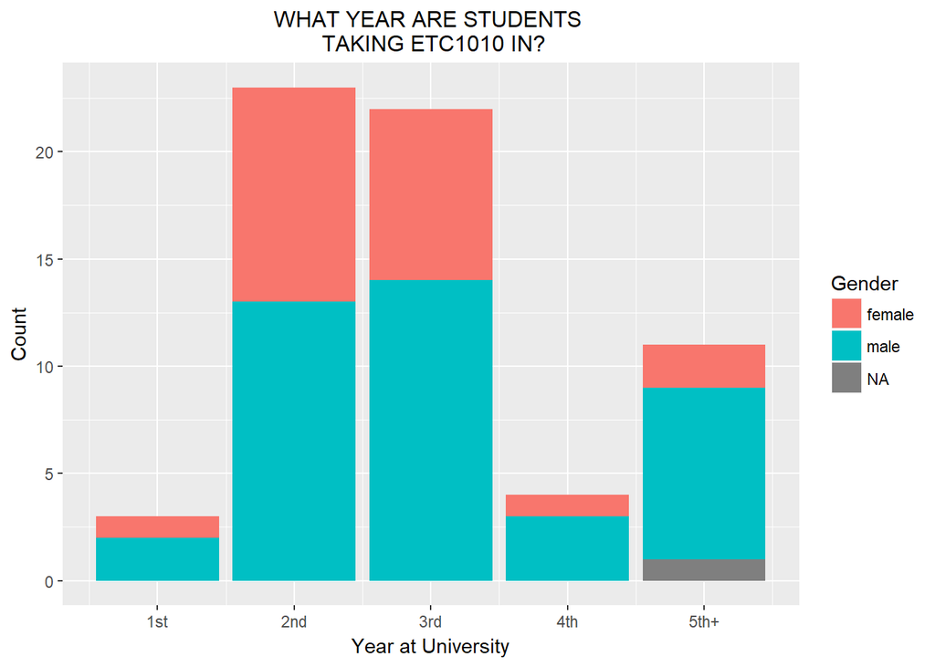

```r
ggplot(cleaned_survey)+geom_bar(aes(cleaned_survey$Q1,fill=cleaned_survey$Q26))+
  scale_x_continuous(breaks=1:5,
                       labels=c("1st","2nd","3rd","4th","5th+"))+
  ggtitle("WHAT YEAR ARE STUDENTS \n TAKING ETC1010 IN?")+
  xlab("Year at University")+ylab("Count")+
  guides(fill=guide_legend(title="Gender"))+
  theme(plot.title = element_text(size=12, hjust=0.5))
```

From this bar chart we gain information regarding the gender and year of study of students taking ETC1010. Interesting to note is that despite ETC1010 being labelled a first year unit, the smallest proportion of first year students are taking this unit relative to students in other years. This unit is most commonly taken by second and third year students. Note also that ETC1010 is more popular with males than females: notable gender imbalance existing for first, fourth and further year students especially. This is aligned with an American Forbes study identifying that approximately 26% of Data Science jobs are held by females (similar to the ratio we see here in this data science unit.) It would be interesting to investigate why there is a higher than average proportion of females in second and third year taking ETC1010.

# Plot 2: Distribution of Travel Time for Single and Double Degree Students

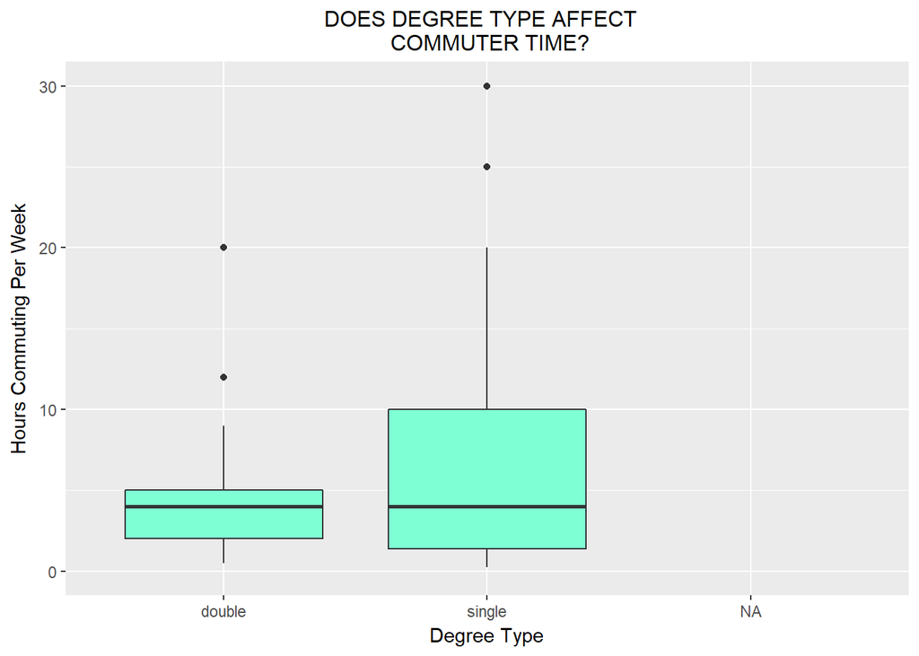

```r
ggplot(cleaned_survey,(aes(cleaned_survey$Q12,cleaned_survey$Q2)))+
  geom_boxplot(fill="aquamarine")+
  scale_y_continuous(limits = c(0, 30))+
ggtitle("DOES DEGREE TYPE AFFECT  \n COMMUTER TIME?")+
  xlab("Degree Type")+ylab("Hours Commuting Per Week")+
  theme(plot.title = element_text(size=12, hjust=0.5))
```

Here we have a comparison of travel time to university for single and double degree students.From this analysis we may be able to draw inferences around the number of contact hours double and single degree students have; maybe meaning that these students are coming to university more often as a result of having more contact hours. The distribution for single degree students is right (positively) skewed meaning that a few sampled individuals have very many travel hours dragging the mean up. Interesting also is the spread being far greater for single degree students. A potential hypothesis for this effect (requiring further investigation) is that single degree students have greater flexibility with electives so there may be a broader range of degrees for those surveyed, single degree students- and therefore greater variation in contact hours. Double degree students who are restricted to picking electives from their domain however, are likely to be doing either Commerce or IT. The outliers for single degree students in particular creates doubt regarding the accuracy of these self- reported values: 30 hours travel time over 5 days implies that one individual spends 6 hours a day travelling. This outlier should probably be excluded.

# Plot 3: Relationship between struggling and enjoying the unit

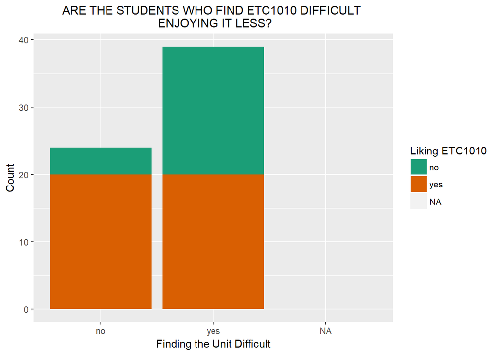

```r
ggplot(cleaned_survey)+
  geom_bar(aes(cleaned_survey$Q30,fill=cleaned_survey$Q31,stat = "identity", position="dodge"))+
    ggtitle("ARE THE STUDENTS WHO FIND ETC1010 DIFFICULT \n ENJOYING IT LESS?")+
  xlab("Finding the Unit Difficult")+ylab("Count")+
  guides(fill=guide_legend(title="Liking ETC1010"))+
  theme(plot.title = element_text(size=12, hjust=0.5))+
  scale_fill_brewer(palette="Dark2")
```

A reasonable assuption to make wold be that students who are finding a unit easy are enjoying it more than students who are finding a unit challenging. From this plot we see that approximately 60% of students are finding the unit difficult but despite this half of these students are still enjoying it. Unsurprisingly, out of the students who are not finding this unit difficult, a strong majority of over 80% are enjoying the unit. This supports the idea that when you understand something, you have a greater capacity to like it.

# Plot 4: Relationship Between Age and Number of Social Outtings

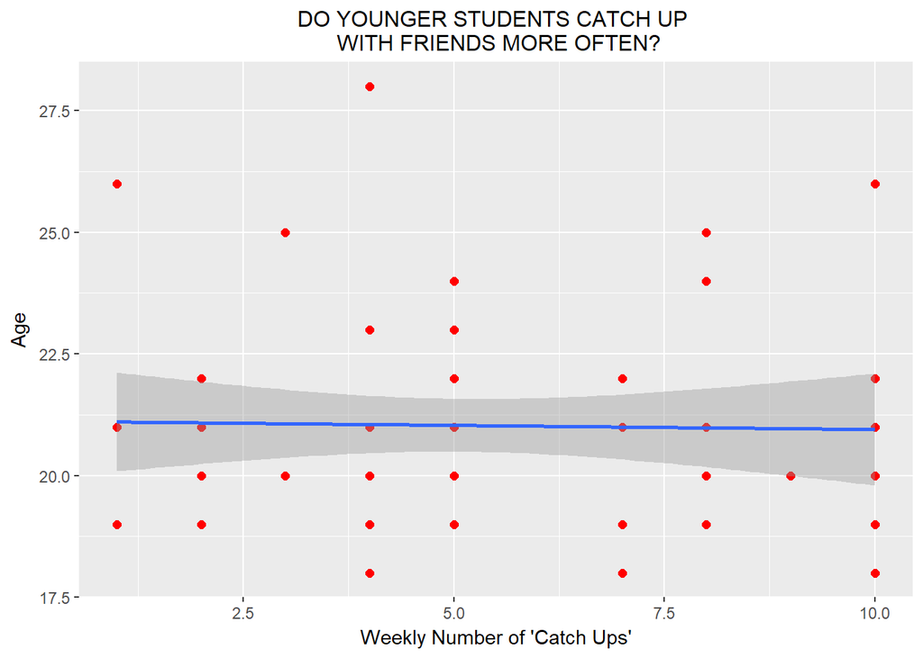

```r
ggplot(cleaned_survey, aes(x=Q22, y=Q23))+
  geom_point(colour="red",size=2)+
  geom_smooth(method="lm")+
  ggtitle("DO YOUNGER STUDENTS CATCH UP \n WITH FRIENDS MORE OFTEN?")+
  xlab("Weekly Number of 'Catch Ups'")+ylab("Age")+
  theme(plot.title = element_text(size=12, hjust=0.5))
```

The purpose of plotting this scatterplot was to see if there was a correlation between age and tendency to socialise. There is a commonly held belief that university students take their final years more seriously than their first so building on that logic we might have expected to see a decline in the number of social ‘catch ups’ as age increased. We could have done this plot comparing ‘year at university’ to ‘social catchups’ rather than age, but this way we get to visualise using non- categorical variables. We observe a rather uniform distribution, the line of best fit being almost parrallel to the x-axis indicating no correlation between age and number of social catch ups. Perhaps the sample was too small or too similar in characteristics so it would be interesting to repeat this comparison with a larger and more diverse sample to see if this commonly held belief holds any merit. #Plot 5: Dot Plot Illustrating Female and Male Heights

[figure not shown]

```r
ggplot(cleaned_survey, aes(cleaned_survey$Q26,cleaned_survey$Q24,colour=cleaned_survey$Q26))+
 geom_point()+
  geom_jitter(width=0.15)+
  ggtitle("DOT PLOT \n REPRESENTING FEMALE \n AND MALE HEIGHTS")+
  xlab("Gender")+ylab("Height(cm")+
  guides(fill=guide_legend(title="Gender"))+
  theme(legend.position="none",plot.title = element_text(size=12, hjust=0.5))
```

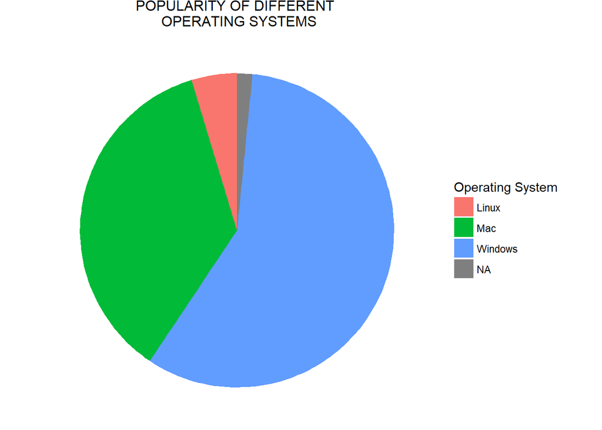

```r
  ggplot(cleaned_survey, aes(x = factor(1), fill = factor(cleaned_survey$Q19))) +
    geom_bar(width = 1)+
    coord_polar(theta = "y")+theme_void()+
    ggtitle("POPULARITY OF DIFFERENT \n OPERATING SYSTEMS")+
    guides(fill=guide_legend(title="Operating System"))+
    theme(plot.title = element_text(size=12, hjust=0.5))
```

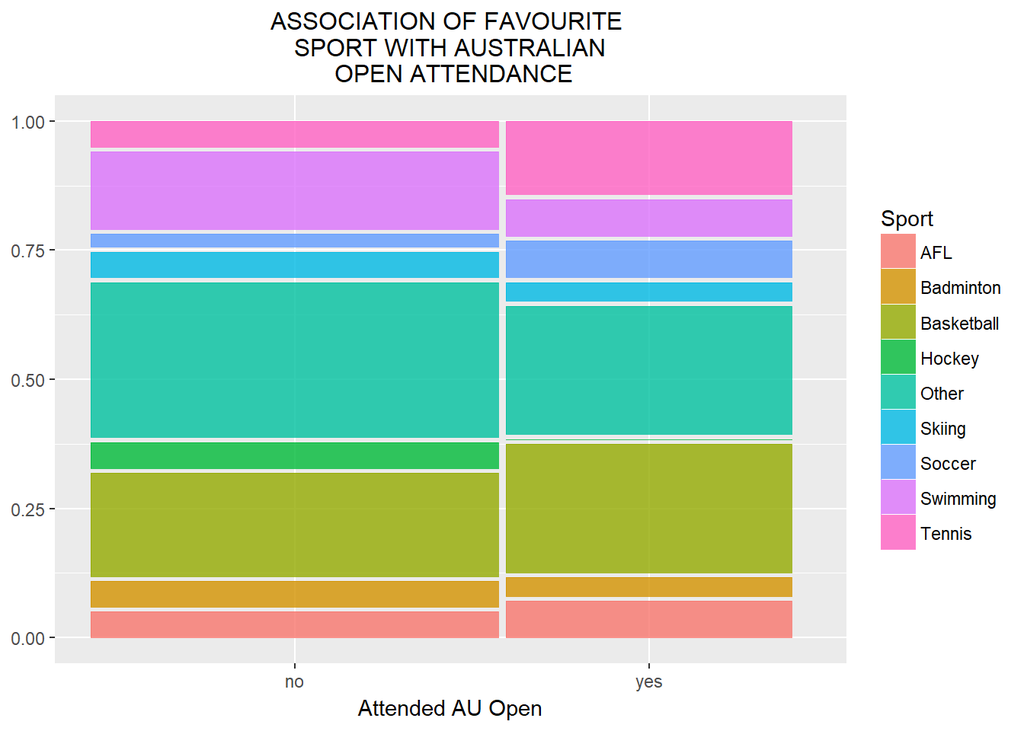

```r
ggplot(cleaned_survey)+
  geom_mosaic(aes(x=product(cleaned_survey$Q29), fill=cleaned_survey$Q25))+
  labs(x="Attended AU Open", title="ASSOCIATION OF FAVOURITE \n SPORT WITH AUSTRALIAN \n OPEN ATTENDANCE")+
  guides(fill=guide_legend(title="Sport"))+
  theme(plot.title = element_text(size=12, hjust=0.5))
```

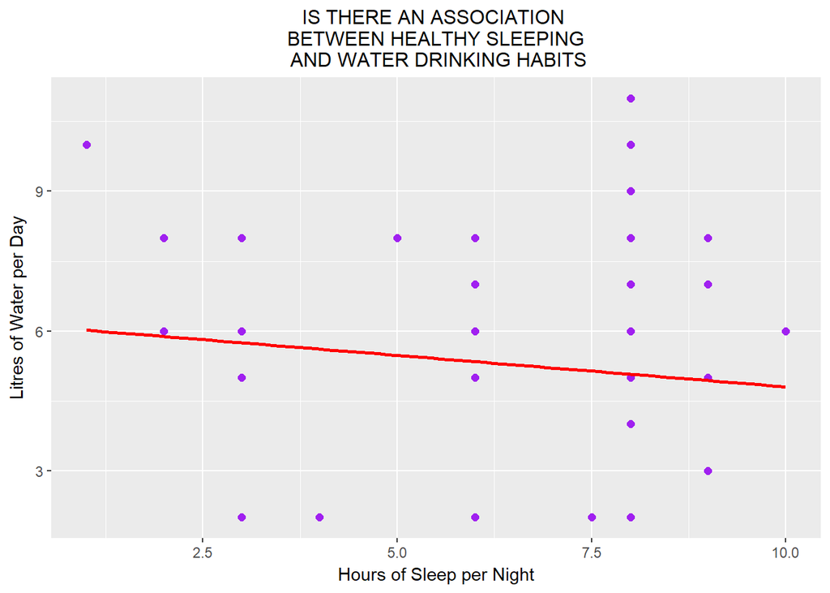

```r
ggplot(cleaned_survey, aes(x=Q21, y=Q10))+
  geom_point(colour="purple",size=2)+
  geom_smooth(method="lm", se=FALSE, colour="red")+
  ggtitle("IS THERE AN ASSOCIATION \n BETWEEN HEALTHY SLEEPING \n AND WATER DRINKING HABITS")+
  xlab("Hours of Sleep per Night")+ylab("Litres of Water per Day")+
  theme(plot.title = element_text(size=12, hjust=0.5))
```

The reason for conducting this scatterplot of litres of water consumed per day against hours of sleep per night was to determine if there was a correlation between these healthy lifestyle habits. A potential hypothesis could be formed suggesting that those who slept more were more conscious of their health and therefore more likely to also be consuming more water. Our analysis disproved this with a weak negative correlation implying that the more an individual within our sample slept, the less likely they were to drink a lot of water. It is again important to be cautious of the sample size and convenient sampling technique used to obtain our sample before we can draw any real conclusions. The most important learning from this plot is our inability to blindly trust data deriving from self - assessment. It is highly likely (and concerning) that a number of individuals reported drinking more than 8 litres of water a day (perhaps misreading the question, confusing litres for no. of cups).